# Presentation training experiment

In this notebook we will see how to use plotly to create graphics, we will create a Machine Learning model that will then be used for deployment

Data contains:

- age - age in years
- sex - (1 = male; 0 = female)
- cp - chest pain type
- trestbps - resting blood pressure (in mm Hg on admission to the hospital)
- chol - serum cholestoral in mg/dl
- fbs - (fasting blood sugar > 120 mg/dl) (1 = true; 0 = false)
- restecg - resting electrocardiographic results
- thalach - maximum heart rate achieved
- exang - exercise induced angina (1 = yes; 0 = no)
- oldpeak - ST depression induced by exercise relative to rest
- slope - the slope of the peak exercise ST segment
- ca - number of major vessels (0-3) colored by flourosopy
- thal - 3 = normal; 6 = fixed defect; 7 = reversable defect
- target - have disease or not (1=yes, 0=no)

```
1    165
0    138
Name: target, dtype: int64
```

[interactive chart not shown]

```
Percentage of Patients Haven't Heart Disease: 45.54%
Percentage of Patients Have Heart Disease: 54.46%
```

```
96
```

[interactive chart not shown]

See what's happend with more variables: Heart Disease Frequency for Ages and sex

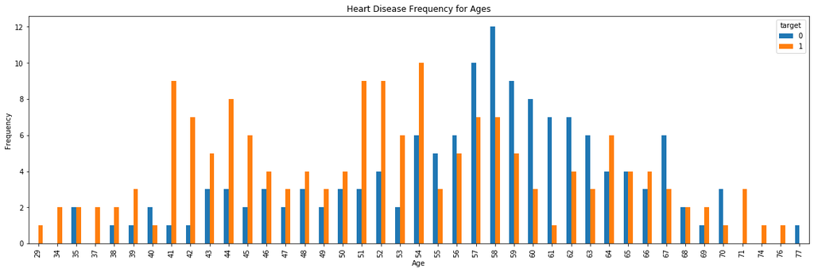

[interactive chart not shown]

### Feature engineering

è vero che la dummizazione può anche essere fatta in pandas e non dipende da trasformazioni precedenti, ma è importante cercare di sforzarsi di fare tutto in sklearn per avere più pulizia e ordine con le librerie che si usano.  
Inoltre Sklearn è fatta per girare su macchine distribuite!!!

```
x_train shape:  (242, 21)
x_test shape:  (61, 21)
y_train shape:  (242,)
y_test shape:  (61,)
```

## Machine Learning Experiments

Try a simple **KNN Model**

```
2 NN Score: 83.61%
```

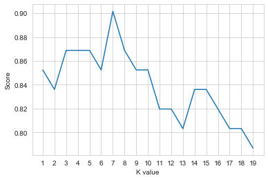

```
Maximum KNN Score is 90.16%
```

the performance are low...so we try to work on the features.

**Normalizing the data** (MinMaxScaler)

Let's try the model again:

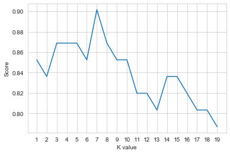

```
Maximum KNN Score is 90.16%
```

Ok let's try with **SVM Classifier**

```
Test Accuracy of SVM Algorithm: 83.61%
```

Let's try a **Decision Tree**

```
Decision Tree Test Accuracy 75.41%
```

And finally a **Random Forest Classification**

```
Random Forest Algorithm Accuracy Score : 85.25%
```

```
RandomForestClassifier(bootstrap=True, ccp_alpha=0.0, class_weight=None,
                       criterion='gini', max_depth=None, max_features='auto',
                       max_leaf_nodes=None, max_samples=None,
                       min_impurity_decrease=0.0, min_impurity_split=None,
                       min_samples_leaf=1, min_samples_split=2,
                       min_weight_fraction_leaf=0.0, n_estimators=500,
                       n_jobs=None, oob_score=False, random_state=42, verbose=0,
                       warm_start=False)
R Squared: 0.319544384761776
```

Visualize the performance

```
{'KNN': 90.1639344262295,
 'SVM': 83.60655737704919,
 'Decision Tree': 75.40983606557377,
 'Random Forest': 85.24590163934425}
```

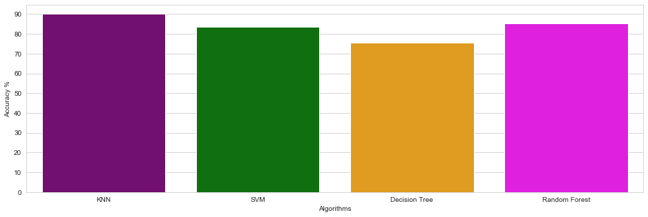

### Evaluation Confusion Matrix

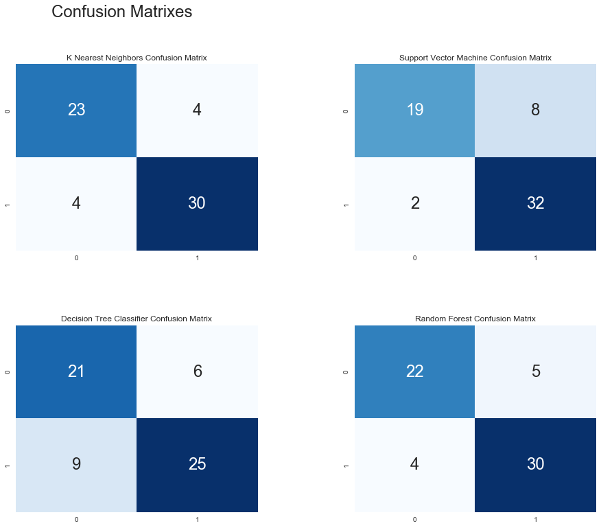

## Save the training Objects

For prediction and production purpose it's important to save training objects:

- transformations
- models

There are several ways to export the results, we will see some..

### ONNX

Open Neural Network Exchange (ONNX) is an open ecosystem that empowers AI developers to choose the right tools as their project evolves. ONNX provides an open source format for AI models, both deep learning and traditional ML. It defines an extensible computation graph model, as well as definitions of built-in operators and standard data types. Currently we focus on the capabilities needed for inferencing (scoring).

ONNX is widely supported and can be found in many frameworks, tools, and hardware. Enabling interoperability between different frameworks and streamlining the path from research to production helps increase the speed of innovation in the AI community. We invite the community to join us and further evolve ONNX.

Onnx = https://github.com/onnx/sklearn-onnx  
Documentation = http://onnx.ai/sklearn-onnx/

save models

```
knn model saved in onnx format
svm model saved in onnx format
dtc model saved in onnx format
rf model saved in onnx format
```

### Input data format for prediction

Analize the input data format to create a new prediction dataset

```
age           int64
sex           int64
cp            int64
trestbps      int64
chol          int64
fbs           int64
restecg       int64
thalach       int64
exang         int64
oldpeak     float64
slope         int64
ca            int64
thal          int64
dtype: object
```

```
 age [29, 34, 35, 37, 38, 39, 40, 41, 42, 43, 44, 45, 46, 47, 48, 49, 50, 51, 52, 53, 54, 55, 56, 57, 58, 59, 60, 61, 62, 63, 64, 65, 66, 67, 68, 69, 70, 71, 74, 76, 77]

 sex [0, 1]

 cp [0, 1, 2, 3]

 trestbps [94, 100, 101, 102, 104, 105, 106, 108, 110, 112, 114, 115, 117, 118, 120, 122, 123, 124, 125, 126, 128, 129, 130, 132, 134, 135, 136, 138, 140, 142, 144, 145, 146, 148, 150, 152, 154, 155, 156, 160, 164, 165, 170, 172, 174, 178, 180, 192, 200]

 chol [126, 131, 141, 149, 157, 160, 164, 166, 167, 168, 169, 172, 174, 175, 176, 177, 178, 180, 182, 183, 184, 185, 186, 187, 188, 192, 193, 195, 196, 197, 198, 199, 200, 201, 203, 204, 205, 206, 207, 208, 209, 210, 211, 212, 213, 214, 215, 216, 217, 218, 219, 220, 221, 222, 223, 224, 225, 226, 227…

 fbs [0, 1]

 restecg [0, 1, 2]

 thalach [71, 88, 90, 95, 96, 97, 99, 103, 105, 106, 108, 109, 111, 112, 113, 114, 115, 116, 117, 118, 120, 121, 122, 123, 124, 125, 126, 127, 128, 129, 130, 131, 132, 133, 134, 136, 137, 138, 139, 140, 141, 142, 143, 144, 145, 146, 147, 148, 149, 150, 151, 152, 153, 154, 155, 156, 157, 158, 159, 16…

 exang [0, 1]

 oldpeak [0.0, 0.1, 0.2, 0.3, 0.4, 0.5, 0.6, 0.7, 0.8, 0.9, 1.0, 1.1, 1.2, 1.3, 1.4, 1.5, 1.6, 1.8, 1.9, 2.0, 2.1, 2.2, 2.3, 2.4, 2.5, 2.6, 2.8, 2.9, 3.0, 3.1, 3.2, 3.4, 3.5, 3.6, 3.8, 4.0, 4.2, 4.4, 5.6, 6.2]

 slope [0, 1, 2]

 ca [0, 1, 2, 3, 4]

 thal [0, 1, 2, 3]
```